# Outbreak analysis template in R

Jcb

21/07/2014

source: Tomas J. Aragon **Applied Epidemiology Using R**, appendix B.

Utilise le package **epitools**, orienté maladies infectieuses. Epitools permet de tracer une courbe épidémique par heure, semaine ou mois. L’information de base est un vecteur de date (i.e ENTREE), chaque date correspondant à la date d’apparition des signes pour 1 individu. Ce vecteur date peut être complété par un vecteur de données qualitatives (sexe, tranche d’age, localisation, etc.) permettant de stratifier e vecteur date.

Exemple de template d’analyse d’une épidémie avec le pckage **epitools**. L’exemple traite d’une épidémie de West Nile Virus (WNV) survenu en Californie en 2004.

Les données source sont acessibles à cette adresse:

```
wnv <-read.table("http://www.medepi.net/data/wnv/wnv2004raw.txt",sep = ",", header = TRUE, na.strings = ".")
```

On les sauvegarde localement:

```
save(wnv, file = "wnv.Rda")
load("wnv.Rda")
```

## Analyse de base

```r
load("wnv.Rda")
str(wnv) #display data set structure
```

```
## 'data.frame':    779 obs. of  8 variables:
##  $ id         : int  1 2 3 4 5 6 7 8 9 10 ...
##  $ county     : Factor w/ 23 levels "Butte","Fresno",..: 14 14 14 14 14 14 14 14 8 12 ...
##  $ age        : int  40 64 19 12 12 17 61 74 71 26 ...
##  $ sex        : Factor w/ 2 levels "F","M": 1 1 2 2 2 2 2 1 2 2 ...
##  $ syndrome   : Factor w/ 3 levels "Unknown","WNF",..: 2 2 2 2 2 2 3 3 2 3 ...
##  $ date.onset : Factor w/ 130 levels "02/02/2005","05/14/2004",..: 4 5 5 3 2 6 8 11 8 10 ...
##  $ date.tested: Factor w/ 104 levels "01/21/2005","02/04/2005",..: 4 5 5 5 5 6 7 8 9 9 ...
##  $ death      : Factor w/ 2 levels "No","Yes": 1 1 1 1 1 1 1 1 1 1 ...
```

```r
head(wnv) #display first 6 lines
```

```
##   id         county age sex syndrome date.onset date.tested death
## 1  1 San Bernardino  40   F      WNF 05/19/2004  06/02/2004    No
## 2  2 San Bernardino  64   F      WNF 05/22/2004  06/16/2004    No
## 3  3 San Bernardino  19   M      WNF 05/22/2004  06/16/2004    No
## 4  4 San Bernardino  12   M      WNF 05/16/2004  06/16/2004    No
## 5  5 San Bernardino  12   M      WNF 05/14/2004  06/16/2004    No
## 6  6 San Bernardino  17   M      WNF 06/07/2004  06/17/2004    No
```

```r
names(wnv) # noms des variables
```

```
## [1] "id"          "county"      "age"         "sex"         "syndrome"
## [6] "date.onset"  "date.tested" "death"
```

## Conversion des dates non-standard en dates juliennes

Une nouvelles colonne est crée, ce qui permet de conserver la colonne d’origine.

```r
wnv$date.onset2 <- as.Date(wnv$date.onset, format="%m/
%d/%Y")
wnv$date.tested2 <- as.Date(wnv$date.tested, format="%
m/%d/%Y")
```

## Afficher l’ histogramme des dates de début (courbe épidémique)

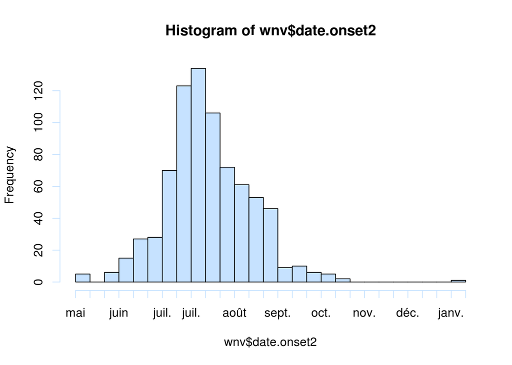

```r
hist(wnv$date.onset2, breaks= 26, freq=TRUE, col="slategray1")
```

## Description d’une variable continue (ex. age)

```r
summary(wnv$age) # no standard deviation provided
```

```
##    Min. 1st Qu.  Median    Mean 3rd Qu.    Max.    NA's
##     1.0    41.0    52.0    52.3    65.0    94.0       6
```

```r
range(wnv$age, na.rm=TRUE);
```

```
## [1]  1 94
```

```r
mean(wnv$age, na.rm=TRUE)
```

```
## [1] 52.29
```

```r
median(wnv$age, na.rm=TRUE);
```

```
## [1] 52
```

```r
sd(wnv$age, na.rm=TRUE)
```

```
## [1] 18.36
```

## Describe continuous variable, stratified by a categorical variable

```r
tapply(wnv$age, wnv$sex, mean, na.rm = TRUE)
```

```
##     F     M
## 53.41 51.66
```

```r
tapply(wnv$age, wnv$county, mean, na.rm = TRUE)
```

```
##          Butte         Fresno          Glenn       Imperial           Kern
##          50.71          52.36            NaN          82.00          47.69
##           Lake         Lassen    Los Angeles         Merced         Orange
##          62.00            NaN          54.12          47.00          55.97
##         Placer      Riverside     Sacramento San Bernardino      San Diego
##          56.00          50.92          56.33          50.83          32.00
##    San Joaquin    Santa Clara         Shasta Sn Luis Obispo         Tehama
##          73.50          50.00          49.20          30.00          46.70
##         Tulare        Ventura           Yolo
##          52.33          37.50          42.00
```

## Display a continuous variable

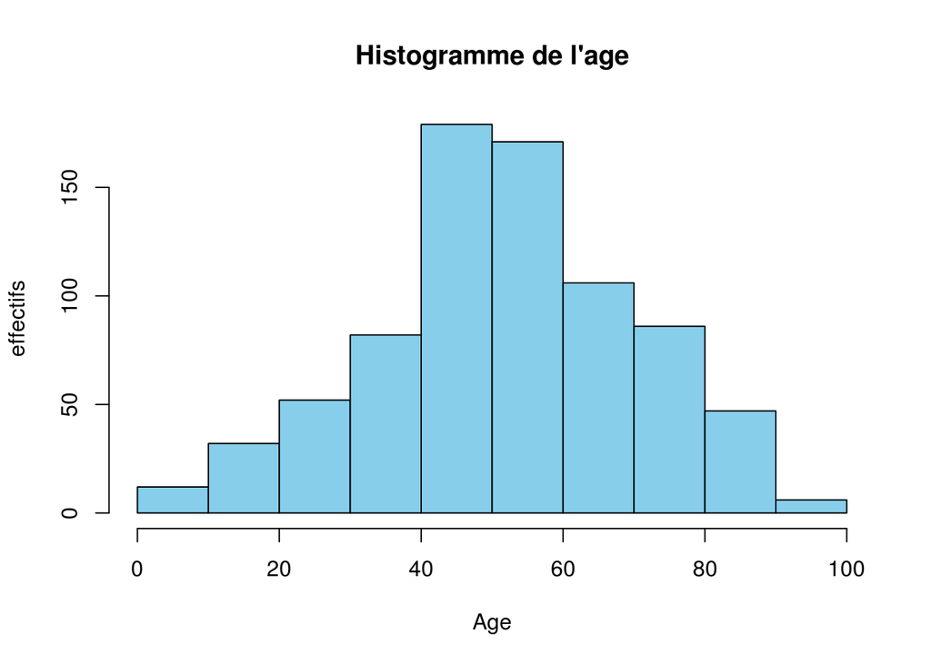

```r
hist(wnv$age, main="Histogramme de l'age", ylab = "effectifs", xlab="Age", col="skyblue")
```

## Description d’une variable catégorielle (e.g., sex)

La fonction **xtabs** forme un tableau croisé ou table de contingence d’une variable possédant plusieurs modalités.

```r
sex.tab <- xtabs(~sex, data = wnv)
sex.dist <- prop.table(sex.tab)
cbind(sex.tab, sex.dist)
```

```
##   sex.tab sex.dist
## F     294   0.3784
## M     483   0.6216
```

## Affichage d’une variable catégorielle

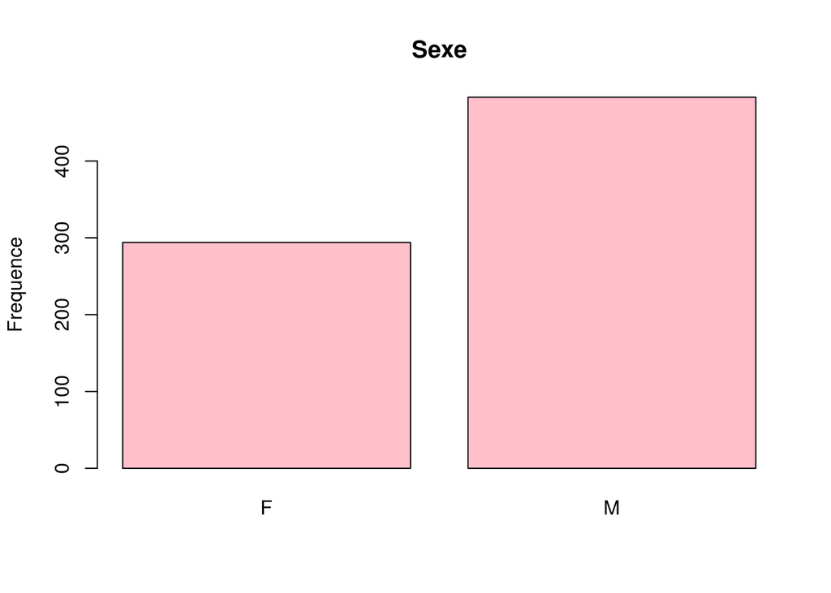

```r
barplot(sex.tab, col="pink", ylab="Frequence", main="Sexe")
```

## Recodage d’une variable continue (ex. age)

```r
wnv$age3 <- cut(wnv$age, breaks=c(0,45,65,100), right=FALSE)
age3.tab <- xtabs(~age3, data = wnv)
age3.dist <- prop.table(age3.tab)
cbind(age3.tab, age3.dist)
```

```
##          age3.tab age3.dist
## [0,45)        240    0.3105
## [45,65)       335    0.4334
## [65,100)      198    0.2561
```

## Décrire deux variales catégorielles (sexe et age)

```r
sexage <- xtabs(~ sex + age3, data = wnv)
sexage
```

```
##    age3
## sex [0,45) [45,65) [65,100)
##   F     86     132       74
##   M    153     203      123
```

```r
prop.table(sexage) #joint distribution
```

```
##    age3
## sex  [0,45) [45,65) [65,100)
##   F 0.11154 0.17121  0.09598
##   M 0.19844 0.26329  0.15953
```

```r
prop.table(sexage, 1) #row distribution
```

```
##    age3
## sex [0,45) [45,65) [65,100)
##   F 0.2945  0.4521   0.2534
##   M 0.3194  0.4238   0.2568
```

```r
prop.table(sexage, 2) #column distribution
```

```
##    age3
## sex [0,45) [45,65) [65,100)
##   F 0.3598  0.3940   0.3756
##   M 0.6402  0.6060   0.6244
```

## Afficher age versus le sexe

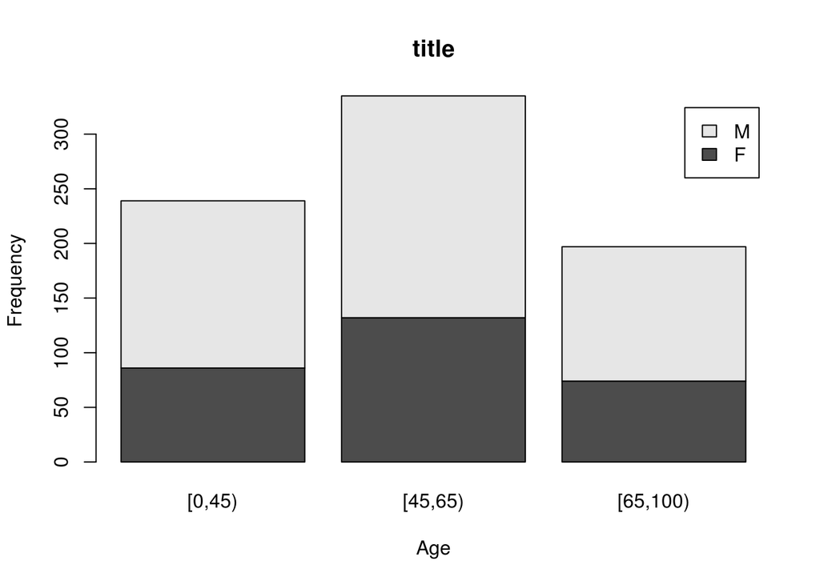

```r
barplot(sexage, legend.text=TRUE,xlab="Age", ylab="Frequency", main="title")
```

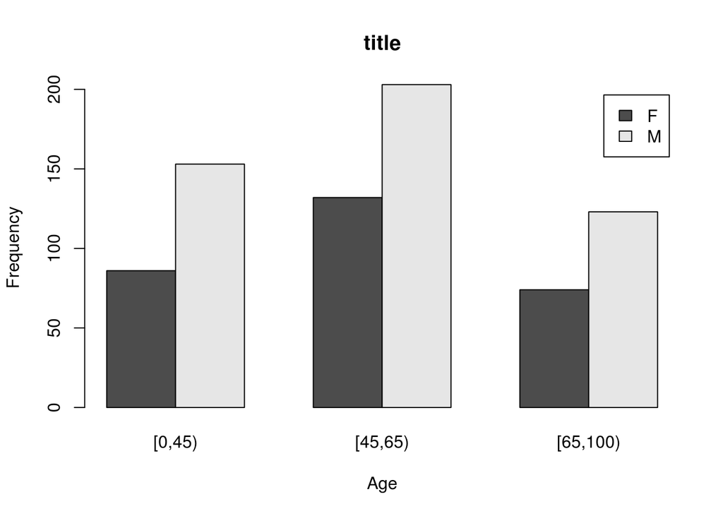

```r
barplot(sexage, legend.text=TRUE, beside=TRUE,xlab="Age", ylab="Frequency", main="title")
```

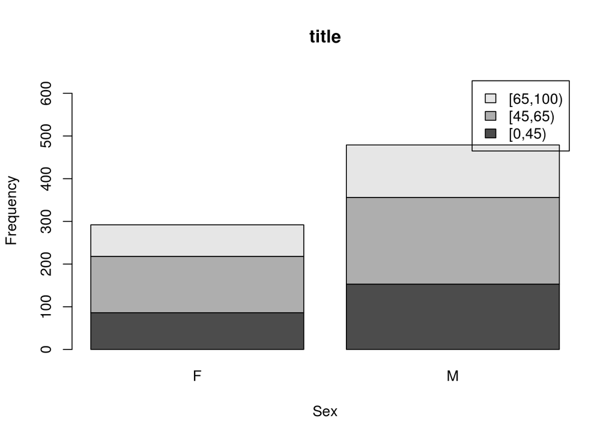

```r
barplot(t(sexage), legend.text=TRUE, ylim=c(0, 650),xlab="Sex", ylab="Frequency", main="title")
```

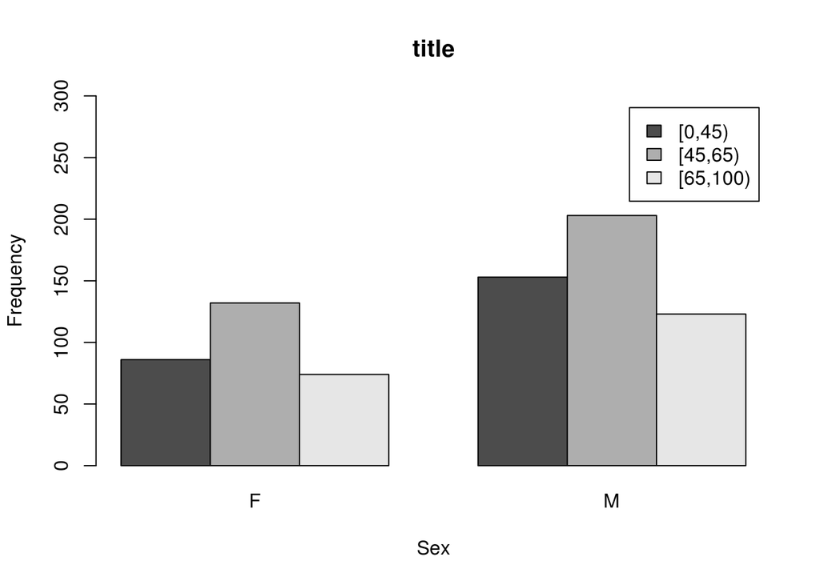

```r
barplot(t(sexage), legend.text=TRUE, beside=TRUE, ylim=c(0, 300),xlab="Sex", ylab="Frequency", main="title")
```

## Hypothesis testing using 2-way contingency tables

```r
library(epitools)
tab.age3 <- xtabs(~ age3 + death, data = wnv)
tab.age3
```

```
##           death
## age3        No Yes
##   [0,45)   217   2
##   [45,65)  302   5
##   [65,100) 163  19
```

```r
epitab(tab.age3) #default is odds ratio
```

```
## $tab
##           death
## age3        No     p0 Yes      p1 oddsratio  lower  upper   p.value
##   [0,45)   217 0.3182   2 0.07692     1.000     NA     NA        NA
##   [45,65)  302 0.4428   5 0.19231     1.796 0.3453  9.345 7.049e-01
##   [65,100) 163 0.2390  19 0.73077    12.647 2.9047 55.067 1.504e-05
##
## $measure
## [1] "wald"
##
## $conf.level
## [1] 0.95
##
## $pvalue
## [1] "fisher.exact"
```

```r
epitab(tab.age3, method = "riskratio")
```

```
## $tab
##           death
## age3        No     p0 Yes       p1 riskratio  lower  upper   p.value
##   [0,45)   217 0.9909   2 0.009132     1.000     NA     NA        NA
##   [45,65)  302 0.9837   5 0.016287     1.783 0.3492  9.108 7.049e-01
##   [65,100) 163 0.8956  19 0.104396    11.431 2.6984 48.427 1.504e-05
##
## $measure
## [1] "wald"
##
## $conf.level
## [1] 0.95
##
## $pvalue
## [1] "fisher.exact"
```

```r
prop.table(tab.age3, 1) #display row distribution (2=column)
```

```
##           death
## age3             No      Yes
##   [0,45)   0.990868 0.009132
##   [45,65)  0.983713 0.016287
##   [65,100) 0.895604 0.104396
```

```r
prop.test(tab.age3[,2:1]) #remember to reverse columns
```

```
##
##  3-sample test for equality of proportions without continuity
##  correction
##
## data:  tab.age3[, 2:1]
## X-squared = 31.9, df = 2, p-value = 1.184e-07
## alternative hypothesis: two.sided
## sample estimates:
##   prop 1   prop 2   prop 3
## 0.009132 0.016287 0.104396
```

```r
chisq.test(tab.age3) #Chi-square test
```

```
##
##  Pearson's Chi-squared test
##
## data:  tab.age3
## X-squared = 31.9, df = 2, p-value = 1.184e-07
```

```r
fisher.test(tab.age3) #Fisher exact test
```

```
##
##  Fisher's Exact Test for Count Data
##
## data:  tab.age3
## p-value = 9.71e-07
## alternative hypothesis: two.sided
```

## Graphical display of epidemiologic data

#### Histogramme (variables continues ou dates)

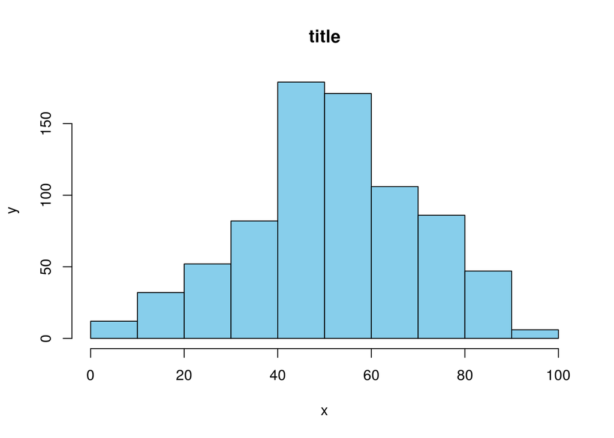

```r
hist(wnv$age, xlab="x", ylab="y", main="title", col="skyblue")
```

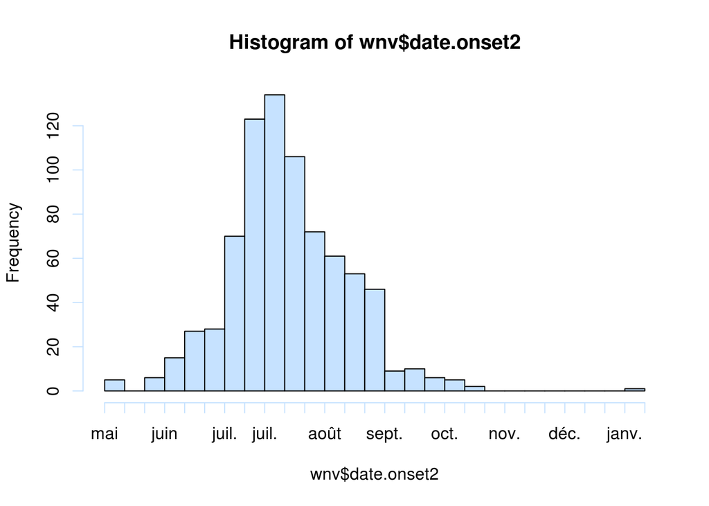

```r
hist(wnv$date.onset2, breaks= 26, freq=TRUE, col="slategray1")
```

#### Barplot (variables catégorielles)

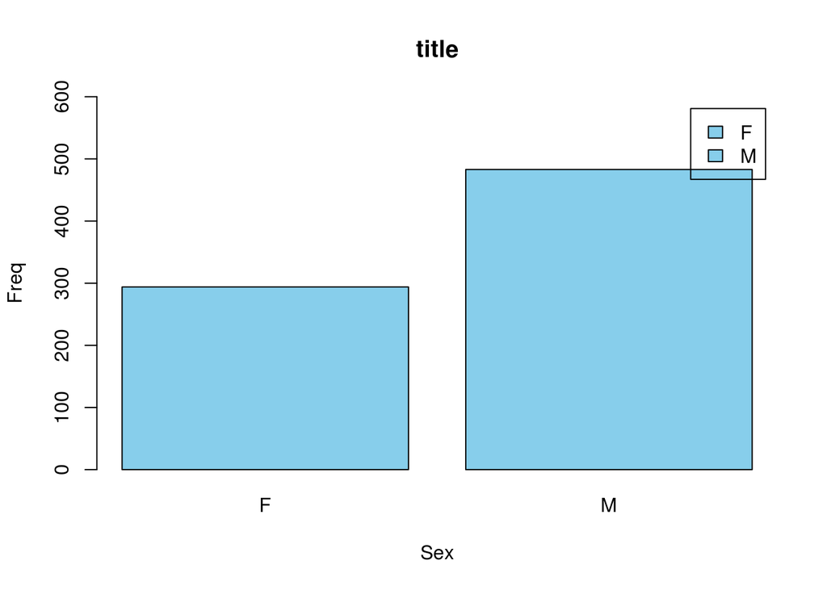

```r
barplot(table(wnv$sex), col="skyblue", xlab="Sex", ylab="Freq",main="title", legend = TRUE, ylim=c(0,600))
```

#### Stacked bar chart (2 variables catégorielles ou plus)

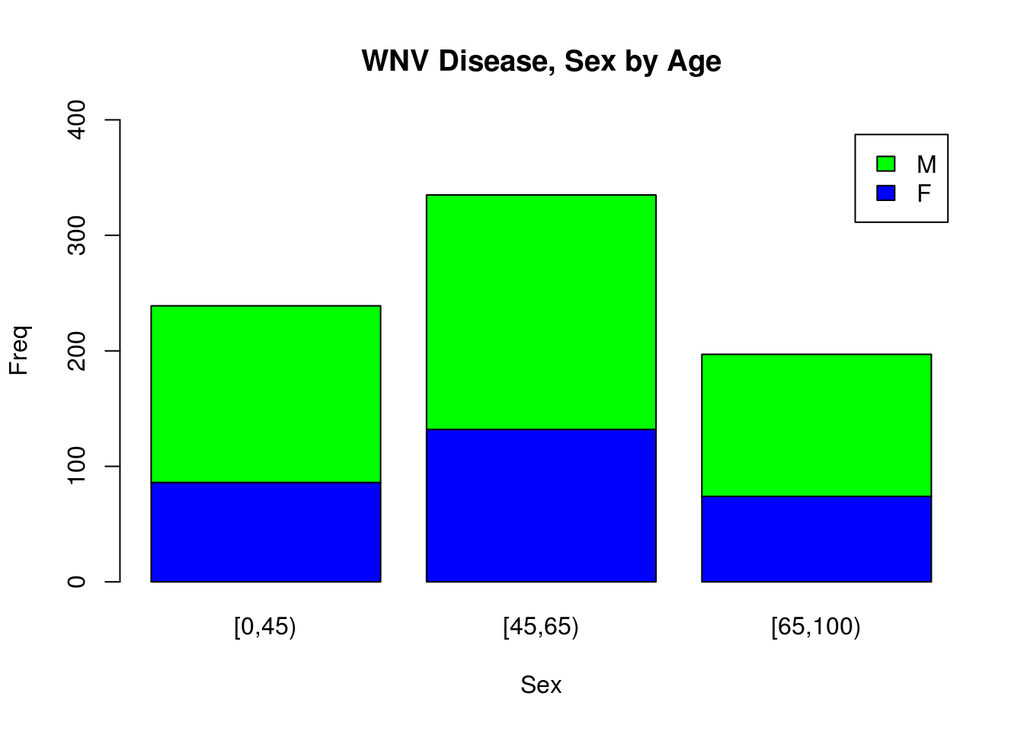

```r
barplot(table(wnv$sex, wnv$age3), col=c("blue","green"), xlab="Sex", ylab="Freq", main="WNV Disease, Sex by Age",legend = TRUE, ylim=c(0,400))
```

#### Group bar chart (2 variables catégorielles ou plus):

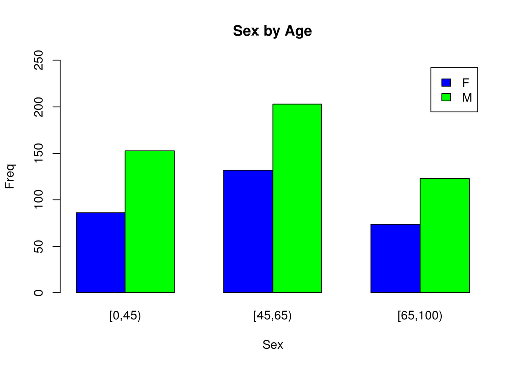

```r
barplot(table(wnv$sex, wnv$age3), beside=TRUE, xlab="Sex",ylab="Freq", main="Sex by Age", col=c("blue","green"),legend = TRUE, ylim=c(0,250))
```

#### Proportion bar chart (2 variables catégorielles ou plus):

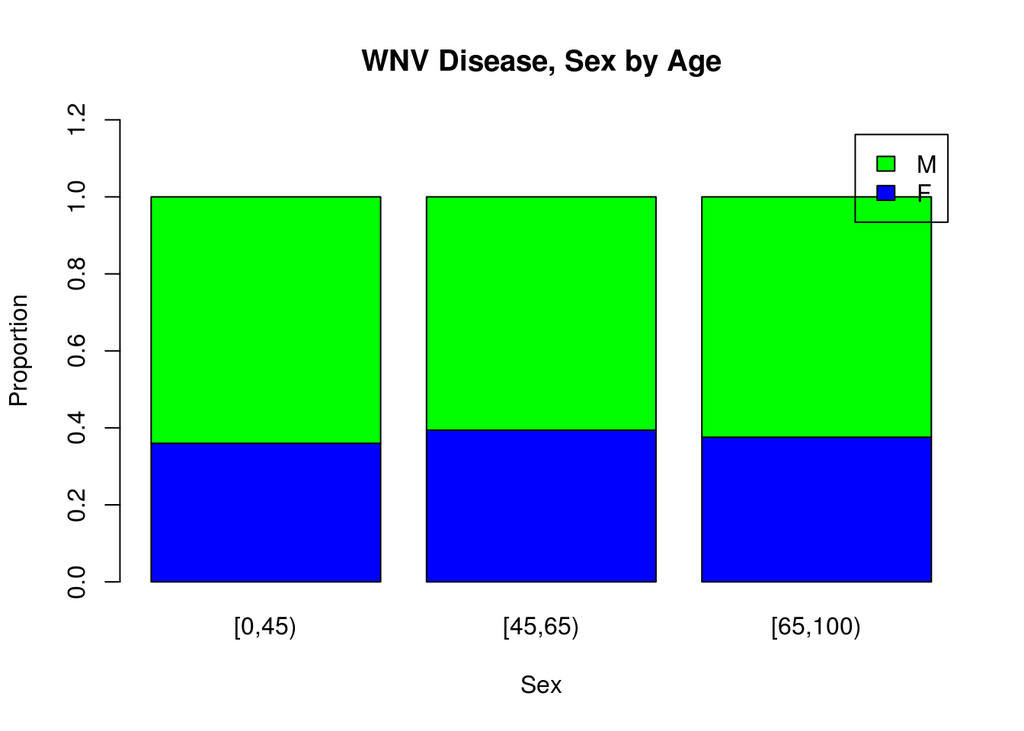

```r
sexage <- xtabs(~ sex + age3, data = wnv)
barplot(prop.table(sexage, 2), xlab="Sex", ylab="Proportion", main="WNV Disease, Sex by Age", col=c("blue","green"),legend = TRUE, ylim=c(0,1.2))
```

## Time series (single x values vs. single y values)

United States measles surveillance data:

measles <- read.table(“http://www.medepi.net/data/measles.txt”,sep=“”, header=TRUE)  
save(measles, file = “Outbreak_Analysis/measles.Rda”)

```r
load("measles.Rda")
str(measles); head(measles)
```

```
## 'data.frame':    52 obs. of  2 variables:
##  $ year : int  1950 1951 1952 1953 1954 1955 1956 1957 1958 1959 ...
##  $ cases: int  319000 530000 683000 449000 683000 555000 612000 487000 763000 406000 ...
```

```
##   year  cases
## 1 1950 319000
## 2 1951 530000
## 3 1952 683000
## 4 1953 449000
## 5 1954 683000
## 6 1955 555000
```

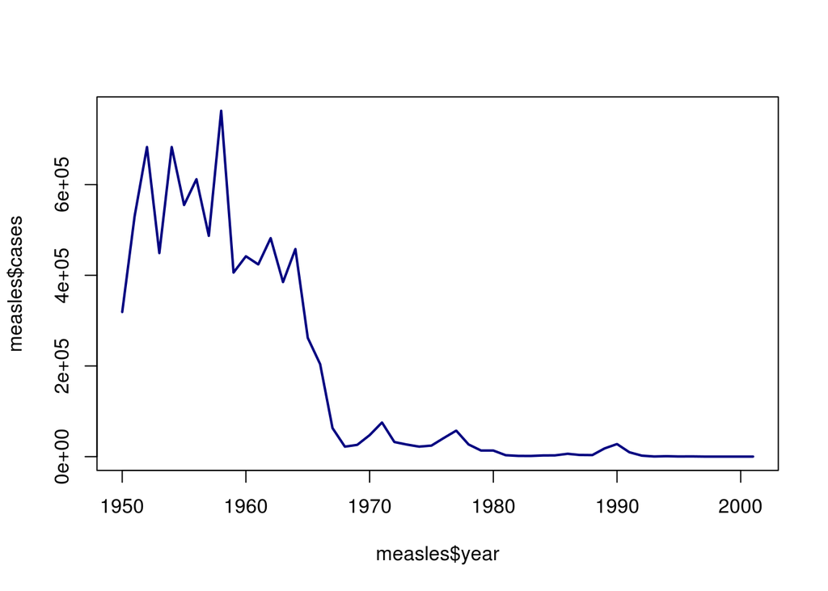

```r
plot(measles$year, measles$cases, type="l", lwd=2, col="navy")
```

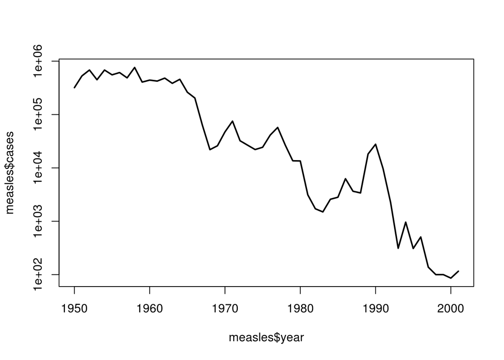

```r
plot(measles$year, measles$cases, type="l", lwd=2, log="y")
```

## Time series (multiple x values vs multiple y values)

United State AIDS and hepatitis B surveillance data

```
aids <- read.table("http://www.medepi.net/data/aids.txt",sep="", header=TRUE, na.strings=".")
hepb <- read.table("http://www.medepi.net/data/hepb.txt",sep="", header=TRUE)
save(hepb, file = "Outbreak_Analysis/hepb.Rda")
save(aids, file = "Outbreak_Analysis/aids.Rda")
```

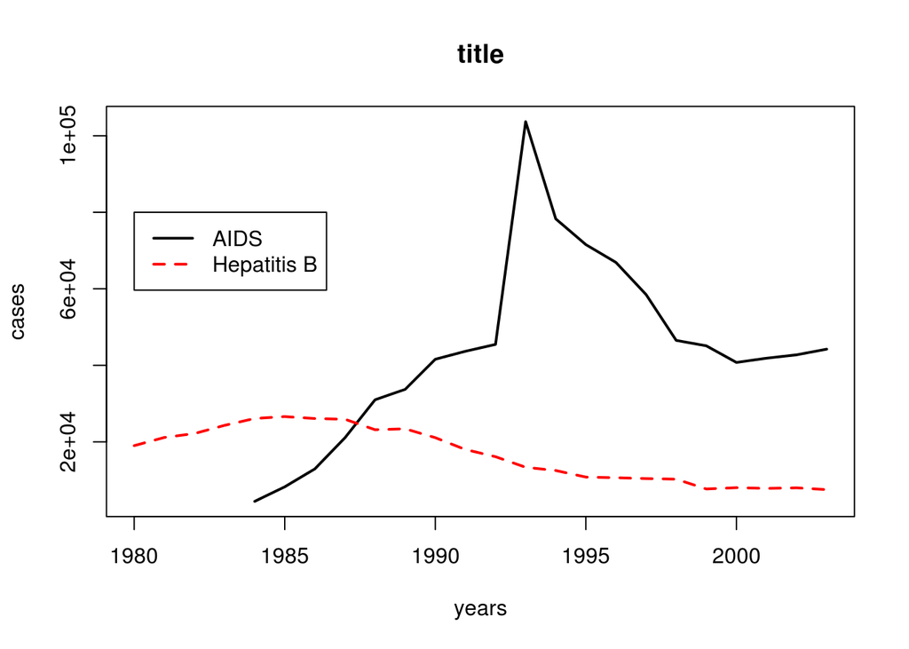

```r
load("aids.Rda")
load("hepb.Rda")
years <- cbind(aids$year, hepb$year)
cases <- cbind(aids$cases, hepb$cases)
matplot(years, cases, type="l", lwd=2, col=1:2, main="title")
legend(x=1980, y=80000, legend= c("AIDS","Hepatitis B"),lty=1:2, col=1:2, lwd=2)
```

## Créer une coube épidémique manuellement

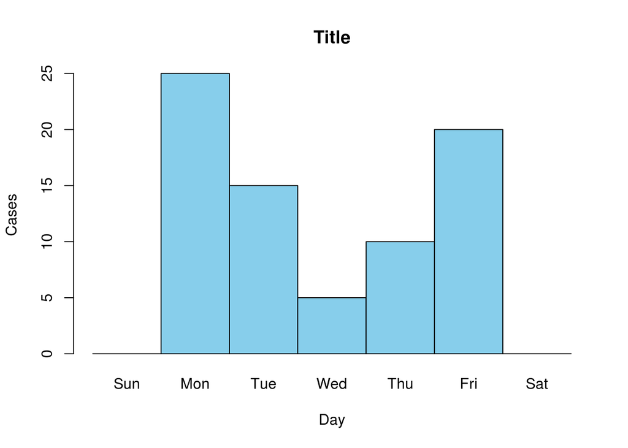

```r
labs <- c("Sun", "Mon","Tue","Wed","Thu","Fri", "Sat")
cases <- c(0, 25, 15, 5, 10, 20, 0)
names(cases) <- labs
barplot(cases, space=0, col="skyblue", xlab="Day", ylab="Cases",main="Title")
```

variante

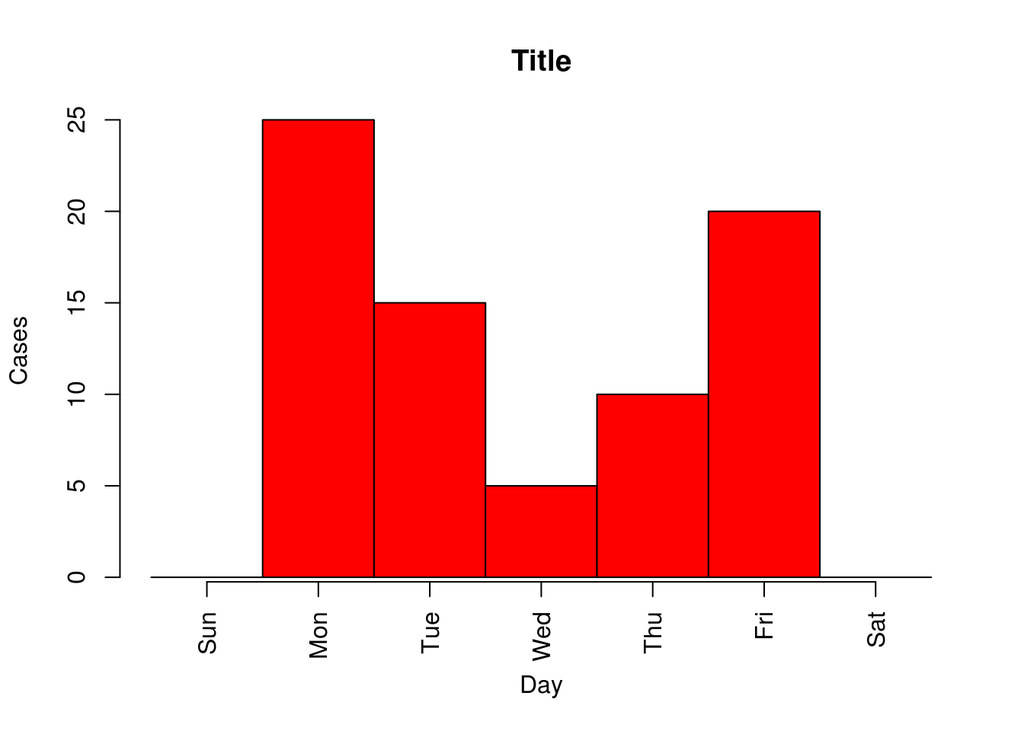

```r
xv <- barplot(cases, space=0, col="red", xlab="Day",ylab="Cases", main="Title", axisnames=FALSE)
axis(side=1, at=xv, labels=labs, las=2)
```

Stratified by second variable

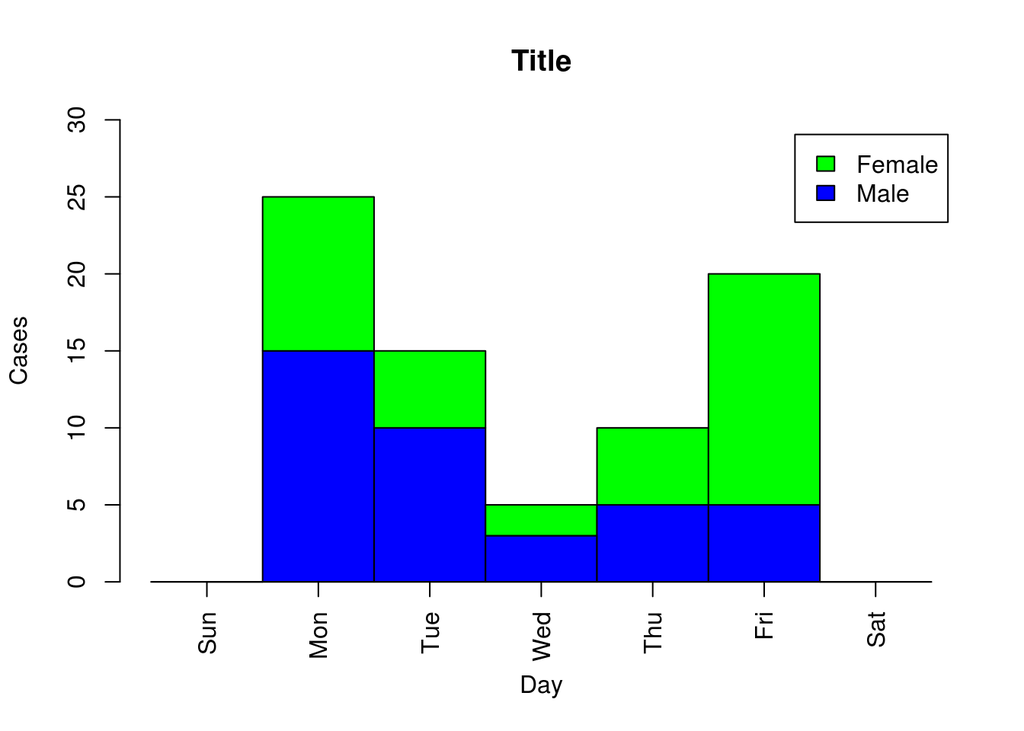

```r
male.cases <- c(0, 15, 10, 3, 5, 5, 0)
female.cases <- c(0, 10, 5, 2, 5, 15, 0)
cases2 <- rbind(Male = male.cases, Female = female.cases)
colnames(cases2) <- labs
xv <- barplot(cases2, space=0, col=c("blue", "green"),xlab="Day", ylab="Cases", main="Title",axisnames=FALSE, legend.text=TRUE, ylim=c(0, 30))
axis(side=1, at=xv, labels=labs, las=2)
```

## Multivariable analysis

Logistic regression (binomial data: cohort, case-control) Using WNV data with age3 variable created previously:

```r
mod1 <- glm(death ~ age3, family=binomial, data=wnv)
mod1 <- glm(death ~ age3, family=binomial, data=wnv)
summary(mod1) #full results
```

```
##
## Call:
## glm(formula = death ~ age3, family = binomial, data = wnv)
##
## Deviance Residuals:
##    Min      1Q  Median      3Q     Max
## -0.470  -0.181  -0.181  -0.136   3.065
##
## Coefficients:
##              Estimate Std. Error z value Pr(>|z|)
## (Intercept)    -4.687      0.710   -6.60  4.2e-11 ***
## age3[45,65)     0.586      0.841    0.70  0.48630
## age3[65,100)    2.537      0.751    3.38  0.00072 ***
## ---
## Signif. codes:  0 '***' 0.001 '**' 0.01 '*' 0.05 '.' 0.1 ' ' 1
##
## (Dispersion parameter for binomial family taken to be 1)
##
##     Null deviance: 222.86  on 707  degrees of freedom
## Residual deviance: 195.66  on 705  degrees of freedom
##   (71 observations deleted due to missingness)
## AIC: 201.7
##
## Number of Fisher Scoring iterations: 7
```

```r
exp(mod1$coef) #calculate odds ratio
```

```
##  (Intercept)  age3[45,65) age3[65,100)
##     0.009217     1.796358    12.647239
```

```r
mod2 <- glm(death ~ age3 + sex, family=binomial, data=wnv)
summary(mod2) #full results
```

```
##
## Call:
## glm(formula = death ~ age3 + sex, family = binomial, data = wnv)
##
## Deviance Residuals:
##    Min      1Q  Median      3Q     Max
## -0.484  -0.187  -0.173  -0.139   3.046
##
## Coefficients:
##              Estimate Std. Error z value Pr(>|z|)
## (Intercept)    -4.784      0.767   -6.23  4.5e-10 ***
## age3[45,65)     0.588      0.842    0.70  0.48499
## age3[65,100)    2.542      0.751    3.39  0.00071 ***
## sexM            0.155      0.429    0.36  0.71807
## ---
## Signif. codes:  0 '***' 0.001 '**' 0.01 '*' 0.05 '.' 0.1 ' ' 1
##
## (Dispersion parameter for binomial family taken to be 1)
##
##     Null deviance: 222.71  on 705  degrees of freedom
## Residual deviance: 195.29  on 702  degrees of freedom
##   (73 observations deleted due to missingness)
## AIC: 203.3
##
## Number of Fisher Scoring iterations: 7
```

```r
exp(mod2$coef) #calculate odds ratio
```

```
##  (Intercept)  age3[45,65) age3[65,100)         sexM
##      0.00836      1.79983     12.70768      1.16764
```

## Utilisation de epicurve

Epicurve permet de tracer des courbes épidémiques avec des données irrégulières et des variables qualitatives à 1 ou plusieurs classes (sexe, tranches d’age, localisation). Il ya plusieurs familles de courbes epicurve, correspondant à des chronologies différentes: - epicurve.dates - epicurve.weeks - epicurve.months - epicurve.hours - epicurve.table

Ces fonctions facilitent le tracé des courbes avec R. Normalement pour tracer une courbe épidémiques dans R, il faut faire ce qui suit: (1) avoir les dates d’apparition d’une maladie au format date, (2) convertir ces dates d’apparition en facteur avec des niveaux spécifiés par la plage de dates du calendrier pour l’axe des x de la courbe de l’épidémique, (3) convertir ce facteur dans une table (avec ou sans stratification), (4) utiliser ce tableau comme un argument dans la fonction barplot pour tracer la courbe épidémique, et (5) faire les derniers ajustements (étiquettes, titres, etc.)

Pourquoi utiliser la fonction barplot? Strictement parlant, une courbe épidémique est un histogramme illustrant la répartition des dates d’apparition qui sont classés , par exemple, en dates. Toutefois, les fonctions de l’histogramme semble fonctionner mieux pour les mesures continues (par exemple, taille, poids). En revanche, les courbes épidémiques sont construits à partir des données temporelles qui sont réparties en jours, semaines ou mois. Pour ce type de données catégorielles, un barplot donne un meilleur résultat. La mise en garde, cependant, est que nous avons besoin de spécifier la plage de dates possibles, en semaines, voire en mois pour construire le graphe approprié. Pour ce faire, nous convertissons les données en facteur avec les niveaux spécifiés par les valeurs de dates possibles.

Pour rendre ce processus plus facile, et pour générer des données supplémentaires qui peuventt être utilisées pour annoter votre courbe de épidémique, les fonctions epicurve ont été créés.

Les fonctions épicurve renvoient un objet list contenant de nombreuses données intermédaires qui peuvent être réutilisées.

NB par date julienne on entend le nombre de jours écoulés depuis de 1/1/1970

#### epicurve.dates returns list:

- *$dates* les dates d’entrée sont converties au format de date calendaires standard (class = Date)
- _$dates2_ les dates d'entrée sont converties en facteursdont les niveaux sont déterminés par les dates calendaires ($cdates) utilisées pour plotter la courbe épidémique (class = factor.
- *$xvals* vecteur numérique correspondant aux abcisses de l’axe des X utilisées pour tracer la courbe épidémique. Ces valeurs sont fournies par la fonction barplot. Utile pour positionner la légende.
- *$cdates* calendrier utilisé pour tracer la courbe. Il couvvre toute la période avec une date par jour. Les fonctions *min* et *max* ou *range* permettent de retrouver l’étendue de la période.
- _$cmday_ vecteur contenant le n° du jour (1-31) du calendrier. Correspond à$cdates avec uniquement le n° du jour.
- *$cmonth* idem que précédemment mais avec le nom abrégé du mois (Jan, Feb, Mar, …).
- *$cyear* idem que précédemment mais avec l’année sur 4 chiffres (e.g., 1996, 2001, …)

```r
sampdates <- seq(as.Date("2004-07-15"), as.Date("2004-09-15"), 1)
length(sampdates)
```

```
## [1] 63
```

[figure not shown]

```r
x <- sample(sampdates, 100, rep=TRUE)
a <- epicurve.dates(x)
```

```r
a$dates[1:5]
```

```
## [1] "2004-09-05" "2004-07-15" "2004-07-24" "2004-08-08" "2004-09-05"
```

```r
a$dates2[1:5]
```

```
## [1] <NA> <NA> <NA> <NA> <NA>
## 77 Levels: 2004-07-08 2004-07-09 2004-07-10 2004-07-11 ... 2004-09-22
```

```r
a$xvals[1:15]
```

```
##  [1]  0.5  1.5  2.5  3.5  4.5  5.5  6.5  7.5  8.5  9.5 10.5 11.5 12.5 13.5
## [15] 14.5
```

```r
a$cdates[1:5]
```

```
## [1] "2004-07-08" "2004-07-09" "2004-07-10" "2004-07-11" "2004-07-12"
```

```r
min(a$cdates)
```

```
## [1] "2004-07-08"
```

```r
max(a$cdates)
```

```
## [1] "2004-09-22"
```

```r
range(a$cdates)
```

```
## [1] "2004-07-08" "2004-09-22"
```

```r
a$cmday[1:10]
```

```
##  [1]  8  9 10 11 12 13 14 15 16 17
```

#### epicurve.weeks returns list:

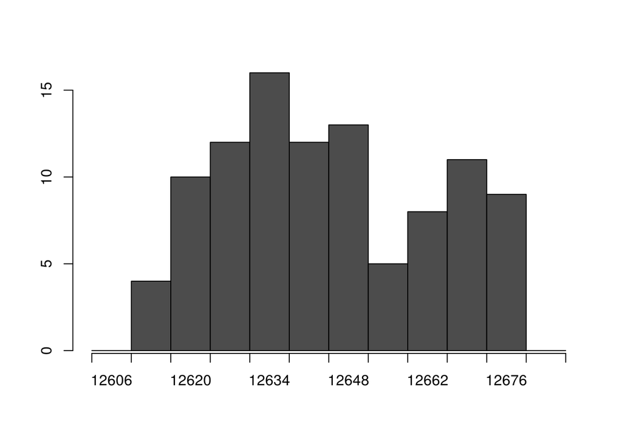

```r
a <- epicurve.weeks(x)
```

```r
a$week[1:15]
```

```
##  [1] "36" "28" "29" "32" "36" "33" "36" "29" "32" "29" "30" "29" "33" "37"
## [15] "33"
```

```r
a$stratum[1:15]
```

```
##  [1] 12669 12613 12620 12641 12669 12648 12669 12620 12641 12620 12627
## [12] 12620 12648 12676 12648
```

```r
min(a$stratum)
```

```
## [1] 12613
```

```r
a$stratum3[1:15]
```

```
##  [1] "2004-09-08" "2004-07-14" "2004-07-21" "2004-08-11" "2004-09-08"
##  [6] "2004-08-18" "2004-09-08" "2004-07-21" "2004-08-11" "2004-07-21"
## [11] "2004-07-28" "2004-07-21" "2004-08-18" "2004-09-15" "2004-08-18"
```

```r
a$stratum2[1:15]
```

```
##  [1] 12669 12613 12620 12641 12669 12648 12669 12620 12641 12620 12627
## [12] 12620 12648 12676 12648
## 12 Levels: 12606 12613 12620 12627 12634 12641 12648 12655 12662 ... 12683
```

```r
a$cstratum2[1:15]
```

```
##  [1] "2004-07-07" "2004-07-14" "2004-07-21" "2004-07-28" "2004-08-04"
##  [6] "2004-08-11" "2004-08-18" "2004-08-25" "2004-09-01" "2004-09-08"
## [11] "2004-09-15" "2004-09-22" NA           NA           NA
```

```r
a$xvals
```

```
##  [1]  0.5  1.5  2.5  3.5  4.5  5.5  6.5  7.5  8.5  9.5 10.5 11.5
```

```r
a$cweek
```

```
##  [1] "27" "28" "29" "30" "31" "32" "33" "34" "35" "36" "37" "38"
```

```r
a$cstratum
```

```
##  [1] 12606 12613 12620 12627 12634 12641 12648 12655 12662 12669 12676
## [12] 12683
## attr(,"origin")
## [1] "1970-01-01"
```

```r
a$cstratum2
```

```
##  [1] "2004-07-07" "2004-07-14" "2004-07-21" "2004-07-28" "2004-08-04"
##  [6] "2004-08-11" "2004-08-18" "2004-08-25" "2004-09-01" "2004-09-08"
## [11] "2004-09-15" "2004-09-22"
```

```r
a$cmday
```

```
##  [1]  7 14 21 28  4 11 18 25  1  8 15 22
```

```r
a$cmonth
```

```
##  [1] "juil." "juil." "juil." "juil." "août"  "août"  "août"  "août"
##  [9] "sept." "sept." "sept." "sept."
```

## epicurve.months returns list:

$dates  
input dates are converted to standard calendar date format

$mon  
month of the year (1-12)

$month  
month of the year (Jan, Feb, Mar, …)

$stratum the Julian date for the mid-month day of the$mon value

$stratum2 the Julian date for the mid-month day of the$mon value converted to a factor with levels determined by the Julian dates ($cstratum)used to plot the epidemic curve

$stratum3 the mid-month day of the$mon value converted to standard calendar dates

$xvals  
x-axis numeric values used for plotting the epidemic curve; this comes from the barplot function

$cmon  
the month of the year (1-12) used for plotting the x-axis of the epidemic curve

$cmonth the months (Jan, Feb, Mar, …) for the calendar dates used for plotting the x-axis of the epidemic curve

$cstratum the Julian date for the mid-month day of the$cmonth value used for plotting the x-axis of the epidemic curve

$cstratum2 the standard calendar date for the mid-month day of the$cmonth value used for plotting the x-axis of the epidemic curve

$cmday  
the day of the mon (1-31) for the calendar dates used for plotting the x-axis of the epidemic curve

$cyear  
the years (e.g., 1996, 2001, …) for the calendar dates used for plotting the x-axis of the epidemic curve

## epicurve.hours returns list:

- *$ct* Date-time object contenant le nombre de secondes depuis 1970 sous forme d’un vecteur numérique et produit par as.POSIXct. On peut utiliser as.POSIXlt pour convertir ce vecteur en quelque chose de lisible pour un humain (already done by this function).
- *sec* secondes
- *$min* minutes
- *$hour* heure (0-23)
- *$hour12* hours (1-12)
- *$stratum* number of hours or 1/2 hours since beginning of 1970
- $stratum2 factor (categorical variable) with number of hours of 1/2 hours since beginning of 1970 using$cstratum as the levels
- $stratum3 factor (categorical variable) in standard date-time format indicating number of hours or 1/2 hours since beginning of 1970 using
- *$xvals*
- _$cstratum_ levels for creating$stratum2 factor
- _$cstratum2_ levels for creating$stratum3 factor
- _$csec_ seconds from$cstratum2
- $cmin minutes from$cstratum2
- $chour hours from$cstratum2 in 24-hour format
- $chour12 hours from$cstratum2 in 12-hour format
- $campm corresponding 'AM' or 'PM' for$chour12
- $campm2 corresponding 'am' or 'pm' for$chour12
- $cweekday day of the week for$cstratum2
- $cwkday abbreviated day of the week for$cstratum2
- $cmday day of the month for$cstratum2
- $cmonth month for$cstratum2
- $cmon abbreviated month for$cstratum2
- $cyear year for$cstratum2
- $half.hour FALSE (default) for 1-hour categories; TRUE for 1/2-hour categories

Exemple d’application: intoxication alimentaire (data oswego): 75 observations et 21 variables (à tester avec le gabarit allemand): - etat-civil: “id”,“age”, “sex” - repas: “meal.time” - malade ou pas: “ill” (o/n) - date et heure des symptomes: “onset.date”, “onset.time” - aliments consommés: “baked.ham”, “spinach”, “mashed.potato”, “cabbage.salad”, “jello”, “rolls”, “brown.bread”, “milk”, “coffee”, “water”, “cakes”, “vanilla.ice.cream”, “chocolate.ice.cream”, “fruit.salad”

```r
data(oswego)
# on crée un vector la date et l'heure du repas en combinant la date du repas le 18/4/1940
mdt <- paste("4/18/1940", oswego$meal.time)
mdt[1:10]
```

```
##  [1] "4/18/1940 8:00 PM"  "4/18/1940 6:30 PM"  "4/18/1940 6:30 PM"
##  [4] "4/18/1940 7:30 PM"  "4/18/1940 7:30 PM"  "4/18/1940 7:30 PM"
##  [7] "4/18/1940 10:00 PM" "4/18/1940 7:00 PM"  "4/18/1940 7:30 PM"
## [10] "4/18/1940 NA"
```

```r
# conversion en date time standard. strptime est une fonction qui convertit une chaine de caractères en objets de la classe posixlt ou posixct
meal.dt <- strptime(mdt, "%m/%d/%Y %I:%M %p")
meal.dt[1:10]
```

```
##  [1] "1940-04-18 20:00:00 WEST" "1940-04-18 18:30:00 WEST"
##  [3] "1940-04-18 18:30:00 WEST" "1940-04-18 19:30:00 WEST"
##  [5] "1940-04-18 19:30:00 WEST" "1940-04-18 19:30:00 WEST"
##  [7] "1940-04-18 22:00:00 WEST" "1940-04-18 19:00:00 WEST"
##  [9] "1940-04-18 19:30:00 WEST" NA
```

```r
# création d'un vecteur avec le date time des premiers signes
odt <- paste(paste(oswego$onset.date,"/1940",sep=""), oswego$onset.time)
odt[1:10]
```

```
##  [1] "4/19/1940 12:30 AM" "4/19/1940 12:30 AM" "4/19/1940 12:30 AM"
##  [4] "4/18/1940 10:30 PM" "4/18/1940 10:30 PM" "4/19/1940 2:00 AM"
##  [7] "4/19/1940 1:00 AM"  "4/18/1940 11:00 PM" "4/19/1940 2:00 AM"
## [10] "4/19/1940 10:30 AM"
```

```r
# conversion en date time standard
onset.dt <- strptime(odt, "%m/%d/%Y %I:%M %p")
onset.dt[1:10]
```

```
##  [1] "1940-04-19 00:30:00 WEST" "1940-04-19 00:30:00 WEST"
##  [3] "1940-04-19 00:30:00 WEST" "1940-04-18 22:30:00 WEST"
##  [5] "1940-04-18 22:30:00 WEST" "1940-04-19 02:00:00 WEST"
##  [7] "1940-04-19 01:00:00 WEST" "1940-04-18 23:00:00 WEST"
##  [9] "1940-04-19 02:00:00 WEST" "1940-04-19 10:30:00 WEST"
```

[figure not shown]

```r
# vecteur des couleurs
col3seq.d <- c("#43A2CA", "#A8DDB5", "#E0F3DB")
par.fin <- par()$fin
par(fin=c(5,3.4))

## 1-hour categories
xv <- epicurve.hours(onset.dt, "1940-04-18 12:00:00", "1940-04-19 12:00:00",axisnames = FALSE, axes = FALSE, ylim = c(0,11),col = col3seq.d[1], segments =  TRUE, strata = oswego$sex)
hh <- xv$chour12==3 | xv$chour12== 6 | xv$chour12== 9
hh2 <- xv$chour12==12
hh3 <- xv$chour12==1
hlab <- paste(xv$chour12,xv$campm2,sep="")
hlab2 <- paste(xv$cmonth,xv$cmday)
axis(1, at = xv$xval[hh], labels = xv$chour12[hh], tick = FALSE, line = -.2)
axis(1, at = xv$xval[hh2], labels = hlab[hh2], tick = FALSE, line = -.2)
axis(1, at = xv$xval[hh3], labels = hlab2[hh3], tick = FALSE, line = 1.0)
axis(2, las = 1)
title(main = "Figure 1. Cas de TIA par heure d'apparition des symptomes (heure) Oswego County, New York, April 18-19, 2004", xlab = "Heure de début", ylab = "Cases")
```

## epicurve.table returns numeric vector:

- xvals x-axis numeric values used for plotting the epidemic curve; this comes from the barplot function

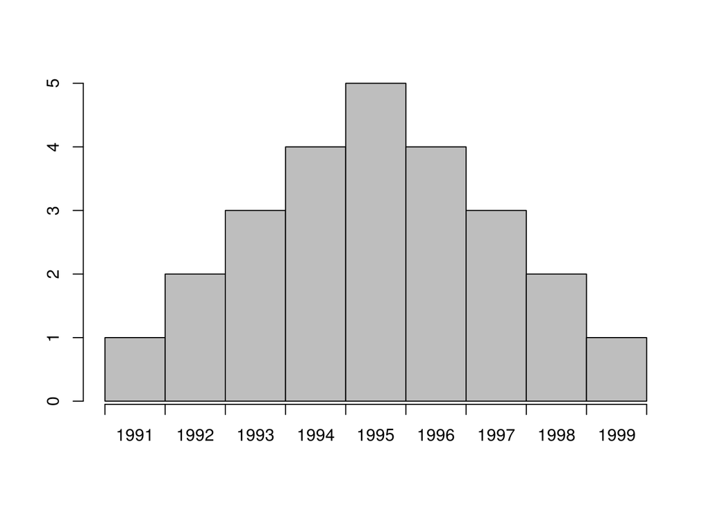

```r
xvec <- c(1,2,3,4,5,4,3,2,1)
names(xvec) <- 1991:1999
epicurve.table(xvec)
```

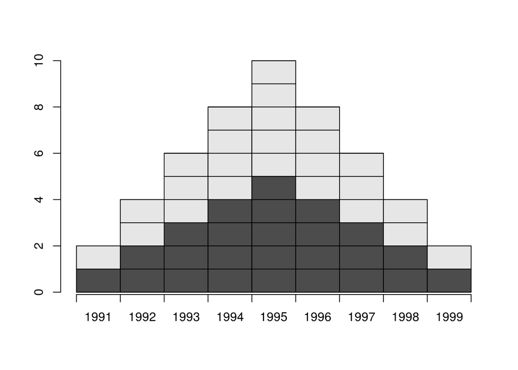

```r
xmtx <- rbind(xvec, xvec)
rownames(xmtx) <- c("Male", "Female")
epicurve.table(xmtx)
epicurve.table(xmtx, seg = TRUE)
```

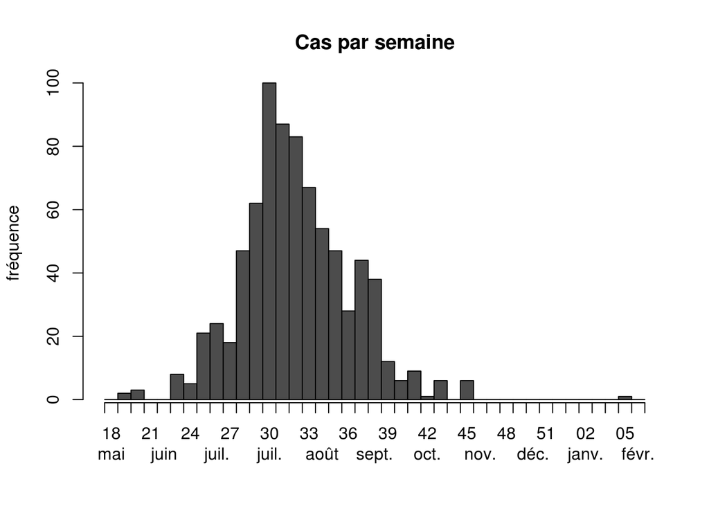

```r
a <- epicurve.weeks(wnv$date.onset2, sunday = FALSE, axisnames = FALSE, main="Cas par semaine", ylab="fréquence")
axis(1, at = a$xvals, labels = a$cweek, tick = FALSE, line = 0)
axis(1, at = a$xvals, labels = a$cmonth, tick = FALSE, line = 1)
```

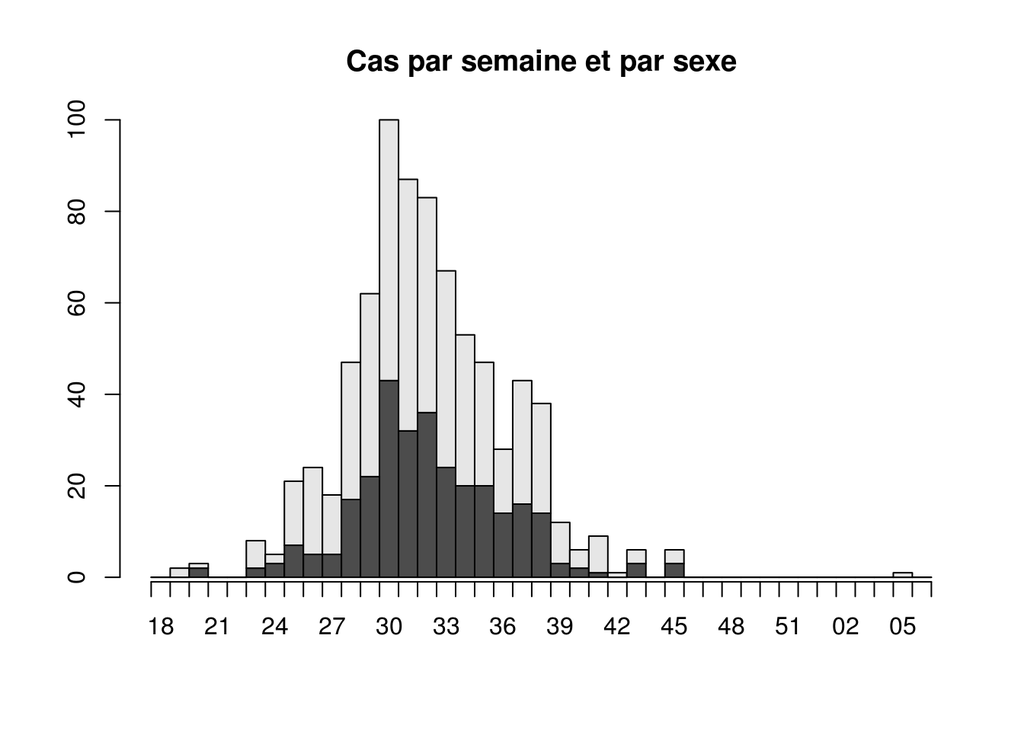

```r
a <- epicurve.weeks(wnv$date.onset2, sunday = FALSE, strata = wnv$sex, axisnames = FALSE, main="Cas par semaine et par sexe")
axis(1, at = a$xvals, labels = a$cweek, tick = FALSE, line = 0)
```

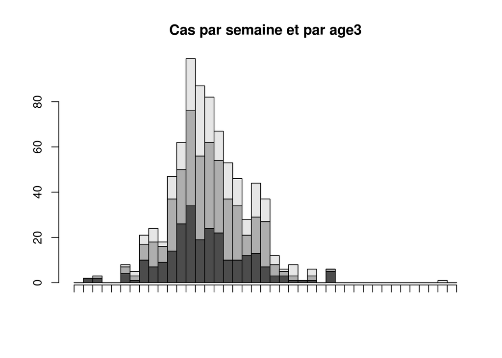

```r
a <- epicurve.weeks(wnv$date.onset2, sunday = FALSE, strata = wnv$age3, axisnames = FALSE, main="Cas par semaine et par age3")
```

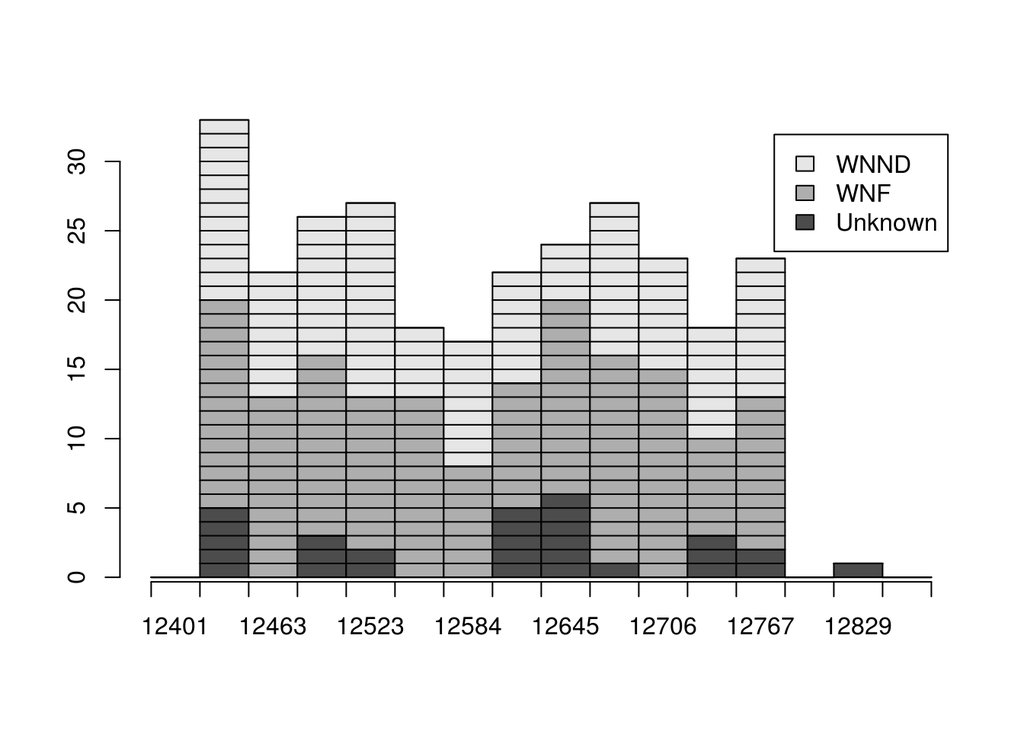

```r
load("wnv.Rda")
epicurve.months(wnv$date.onset, format = "%d/%m/%Y", strata = wnv$syndrome, legend = levels(wnv$syndrome))
epicurve.months(wnv$date.onset, format = "%d/%m/%Y", strata = wnv$syndrome, legend = levels(wnv$syndrome), segments = TRUE)
```

Les autres éléments utiles du graphe héritent de barplot:

- cex.names taille des caractères de l’axe des X
- las = 2 orientation verticale de l’axe des X
- width = 0.3 pour avoir des barplot étroits. Pour que cela ait un effet, il faut ajouter xlim=c(0,20) par ex.
- col = heat.colors(3) pour colorier avec 3 couleurs (jaune, orange, rouge)

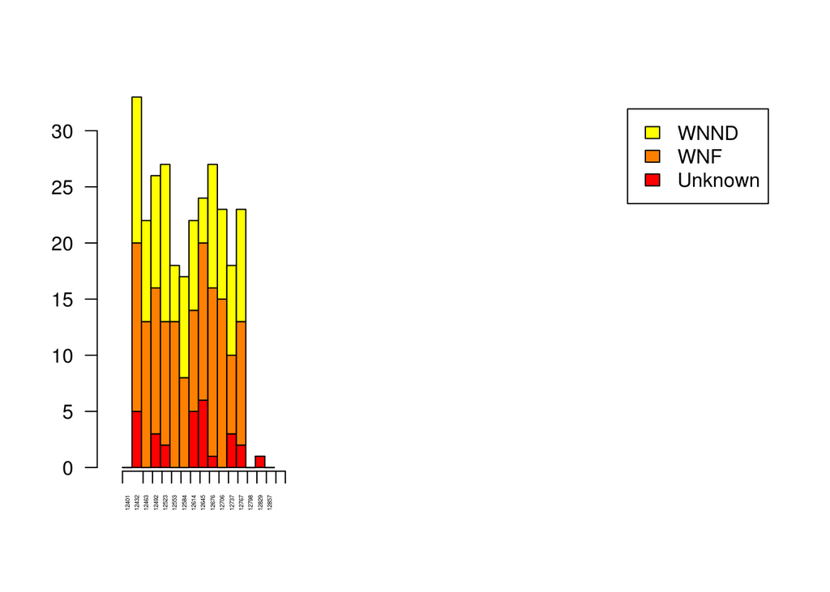

```r
epicurve.months(wnv$date.onset, format = "%d/%m/%Y", strata = wnv$syndrome, legend = levels(wnv$syndrome), col = heat.colors(3), width = 0.3, xlim=c(0,20), las=2, cex.names=0.3)
```

# Notion de standardisation

Analyse de l’article du Bulletin épidémiologique vol.23 n°3 de septembre 2002. *Epitools* possède 2 fonctions por faire de la standardisation directe et indirecte mais elles supposent que l’on utilise des données brutes. L’article explique les 2 méthodes de standardisation à partir d’exemple où les taux sont déjà connus. Dans ce cas un calcul manuel est plus rapide.

## Méthode directe

On compare les taux de mortalité entre le Mexique et les USA en utilisant une population type définie par Waterhouse:

```r
stdpop <- c(2400,9600,19000,17000,26000,19000,7000)
dir <- data.frame(stdpop=c(2400,9600,19000,17000,26000,19000,7000))
Age <- c(">1", "1-4","5-14", "15-24", "25-44", "45-64", "65+")
```

Le taux de mortalité brut pour les USA en 1995-97 est de 8.7 pour1000 habitant contre 4.7 pour le mexique. Cependant la structure d’age n’est pas la même entre ces 2 pays. Pour éliminer ce biais on standardise la mortalité en éliminant l’influence de l’age. Pour cela on a besoin des taux de mortalité des deux pays dans les mêmes strates d’age.

Taux de mortalité par groupe d’age pour 100.000 h au Mexique:

```r
mexique <- c(1693.2,112.5,36.2,102.9,209.6,841.1,4967.4)
```

Taux de mortalité par groupe d’age pour 100.000 h aux USA:

```r
usa <- c(737.8,38.5,21.7,90.3,176.4,702.3,5062.6)
```

Puis on va appliquer ces taux à la population standard:

```r
deces.attendus.mex <- mexique * stdpop/100000
deces.attendus.usa <- usa * stdpop/100000
```

- taux de mortalité ajusté pour l’age - Mexique: 6.4 pour 1000
- taux de mortalité ajusté pour l’age - USA: 5.7 pour 1000

Tableau récapitulatif:

```r
Age <- c(">1", "1-4","5-14", "15-24", "25-44", "45-64", "65+")
dir <- data.frame(Age, stdpop, mexique, usa, deces.attendus.mex, deces.attendus.usa)
dir
```

```
##     Age stdpop mexique    usa deces.attendus.mex deces.attendus.usa
## 1    >1   2400  1693.2  737.8             40.637             17.707
## 2   1-4   9600   112.5   38.5             10.800              3.696
## 3  5-14  19000    36.2   21.7              6.878              4.123
## 4 15-24  17000   102.9   90.3             17.493             15.351
## 5 25-44  26000   209.6  176.4             54.496             45.864
## 6 45-64  19000   841.1  702.3            159.809            133.437
## 7   65+   7000  4967.4 5062.6            347.718            354.382
```

```r
tot <-colSums(dir[,-1])
a <- c("total",tot)
dir$Age <- as.character(dir$Age)
dir <- rbind(dir,a)
```